# Creating Pan-Arctic and Bering Sea ocean acidification pressure layers for the ice and ice free seasons

Jamie Afflerbach

11/10/2015

This script creates the OA stressor layers for pan-arctic and bering strait region.

## Overview

The ‘oa_seasonal_dataprep.Rmd’ calculated mean seasonal aragonite saturation state. The seasons are:

1. **ice**: November to May of the next year. Since the raw data goes from 1880-1889 and 2005-2014, for each decade we have just 9 sesaonal averages due to cross year inclusion in the ice season.
2. **ice-free**: June to October

This script takes prepped Ocean Acidification input raster layers (created by oa_dataprep.R) and does the following:

[output not shown]

While this script calculates OA for pan-arctic and, just clips the output layer to the bering strait. There are built in functions that allow for the BSR region to be calculated without the pan-arctic calculation.

*NOTE: Interpolation was done in ArcGIS using OA_interpolation.py*

## Data

```r
hist_ice_mean = raster('working/annualmean_1880-1889_iceseason/decadal_mean_1880-1889_ice.tif') # historical decadal mean of aragonite saturation state from 1880-1889 in the ice season

hist_icefree_mean = raster('working/annualmean_1880-1889_icefreeseason/decadal_mean_1880-1889_icefree.tif') # historical decadal mean of aragonite saturation state from 1880-1889 in the ice-free season

ice_files = list.files('working/annualmean_2005-2014_iceseason',full.names=TRUE,recursive=TRUE)

icefree_files = list.files('working/annualmean_2005-2014_icefreeseason',full.names=TRUE,recursive=TRUE)
```

## Methods

### Step 1: Clip data to bsr and panarctic

```r
pan_mask = function(file, season){

  if(season=='ice'){
  yr = substr(file,72,76)
  }else{
  yr = substr(file,80,83)}
  r = raster(file)
  crop = crop(r,pan)
  mask_r = mask(crop,pan,progress='text')
  if(season=='ice'){
  writeRaster(mask_r,filename=paste0('working/pan-arctic/ice_season/raw_crop/oa_raw_crop_',yr,sep=''),format='GTiff',overwrite=T)
  }else{
  writeRaster(mask_r,filename=paste0('working/pan-arctic/icefree_season/raw_crop/oa_raw_crop_',yr,sep=''),format='GTiff',overwrite=T)
  }
}

sapply(ice_files,pan_mask,season='ice') #set season to either 'ice' or 'icefree'
sapply(icefree_files,pan_mask,season='icefree') #set season to either 'ice' or 'icefree'

# also do the same for historical mean

pan_hist = hist_ice_mean%>%
            crop(.,pan)%>%
              mask(.,pan,filename='working/pan-arctic/ice_season/raw_crop/hist_mean_1880_1889_ice_crop.tif',
                   overwrite=T,progress='text')

pan_hist_icefree = hist_icefree_mean%>%
            crop(.,pan)%>%
              mask(.,pan,filename='working/pan-arctic/icefree_season/raw_crop/hist_mean_1880_1889_icefree_crop.tif',
                   overwrite=T,progress='text')
```

Plot

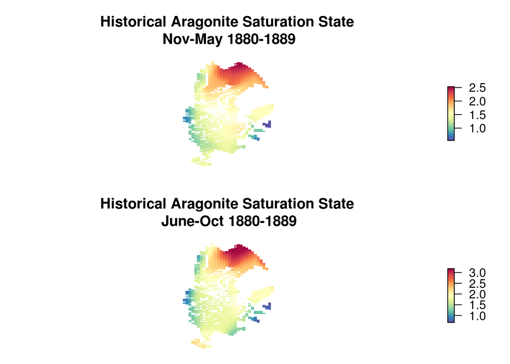

```r
pan_hist=raster('working/pan-arctic/ice_season/raw_crop/hist_mean_1880_1889_ice_crop.tif')
pan_hist_icefree = raster('working/pan-arctic/icefree_season/raw_crop/hist_mean_1880_1889_icefree_crop.tif')

par(mfrow=c(2,1),mar=c(1,2,4.1,2.1))

plot(pan_hist,col=cols,box=F,axes=F,main='Historical Aragonite Saturation State\n Nov-May 1880-1889')
plot(pan_hist_icefree,col=cols,box=F,axes=F,main='Historical Aragonite Saturation State\n June-Oct 1880-1889')
```

### Step 2: function that subtracts annual mean from historical decadal mean and outputs raster to specified folder.

This function takes the annual average for each ice and ice free season and compares to the historical mean for that season. The **percent change** is calculated. As an example, if a cell in the ice season historically had a mean aragonite saturation state of 2, but now is on average 1.6, the resulting value for that cell will be 0.2. This corresponds with a 20% decrease in saturation state.

For cells that have increased over time, these will show as negative values and will eventually be given a value of 0 as we are only interested in acidifying regions.

```r
pan_annual_change = function(file,season){

  if(season=='ice'){

      yr = substr(file,52,56)         #use substr to grab the year out of the filename

      out = (pan_hist - raster(file))/pan_hist   #subtract current from historical. Although this is counterintuitive, it results in the
                                      #correct scaling of values (higher values = more acidification)

  writeRaster(out,filename=paste0('working/pan-arctic/ice_season/annualchange/difference_from_hist_mean_',yr,sep=""),
              format='GTiff',overwrite=T)

  }else{

    yr=substr(file,56,59)

    out = (pan_hist_icefree - raster(file))/pan_hist_icefree   #subtract current from historical. Although this is counterintuitive, it results in the
                                            #correct scaling of values (higher values = more acidification)

    writeRaster(out,filename=paste0('working/pan-arctic/icefree_season/annualchange/difference_from_hist_mean_',yr,sep=""),
                format='GTiff',overwrite=T)
  }
}

#list files to apply function to
    panfiles_ice = list.files(path = 'working/pan-arctic/ice_season/raw_crop',
                              pattern='oa_*',full.names=T)
    panfiles_icefree = list.files(path = 'working/pan-arctic/icefree_season/raw_crop',
                                  pattern='oa_*',full.names=T)


# apply function across all files using sapply
    sapply(panfiles_ice,pan_annual_change,season='ice')
    sapply(panfiles_icefree,pan_annual_change,season='icefree')
```

### Step (3): Rescale values

For each year between 2005 and 2014, look at the mean annual aragonite saturation state rasters (annualmean_2005-2014). All values at or below the threshold (<=1) are set to 1 (highest pressure value). All cells with aragonite saturation state values >1, will be scaled based on their change relative to historical levels (calculated in step 2 above).

```r
#list files for annual change calculated in previous step. These are referenced within the function

    pan_change_ice     = list.files('working/pan-arctic/ice_season/annualchange',full.names=TRUE,recursive=TRUE)
    pan_change_icefree = list.files('working/pan-arctic/icefree_season/annualchange',full.names=TRUE,recursive=TRUE)

#Function

pan_rescale = function(file, season){

  if(season=='ice'){

  yr   = substr(file,52,56)         #get year of file
  mean = raster(file)               #get seasonal mean aragonite raster for given year
  diff = raster(pan_change_ice[substr(pan_change_ice,70,74)==yr])  #get the change raster for same year

  #out = overlay(mean,diff,fun=function(x,y){y^(x-1)})

  mean[mean<=1]<-1                                #all values at or less than 1 are given a value of 1
  mean[mean>1] = diff[mean>1]                      #all cells with values greater than 1 are swapped out with their amount of change scaled to how close to 1
  mean[mean<0]<-0                                 #all values less than 0 (indicating a decrease in acidity) are capped at 0

  writeRaster(mean,filename=paste0('working/pan-arctic/ice_season/rescaled/oa_rescaled_',yr,sep=""),format='GTiff',overwrite=T)

  }else{

      yr   = substr(file,56,59)                                                #get year of file
      mean = raster(file)                                                      #get annual mean aragonite raster for given year
      diff = raster(pan_change_icefree[substr(pan_change_icefree,74,77)==yr])  #get the change raster for same year

      #out = overlay(mean,diff,fun=function(x,y){y^(x-1)})

      mean[mean<=1]<-1                             #all values at or less than 1 are given a value of 1
      mean[mean>1] = diff[mean>1]                   #all cells with values greater than 1 are swapped out with their amount of change scaled to how close to 1
      mean[mean<0]<-0                              #all values less than 0 (indicating a decrease in acidity) are capped at 0

      writeRaster(mean,filename=paste0('working/pan-arctic/icefree_season/rescaled/oa_rescaled_',yr,sep=""),
                format='GTiff',overwrite=T)

  }

}

# list files

    ice_avgs     = list.files('working/pan-arctic/ice_season/raw_crop',pattern='oa_*',full.names = T)
    icefree_avgs = list.files('working/pan-arctic/icefree_season/raw_crop', pattern='oa_*',full.names=T)


# apply function to files

sapply(ice_avgs,pan_rescale, season='ice')
sapply(icefree_avgs,pan_rescale, season='noice')
```

### Step 3: Resample to 1km

```r
pan_resample = function(file,season){

  if(season=='ice'){

    yr  = substr(file,52,56)
    r   = raster(file)
    out = raster::resample(r,pan_ocean,method='ngb',progress='text') # resample r to the resolution of 'ocean' (~1km)

    writeRaster(out,filename=paste0('working/pan-arctic/ice_season/rescaled_1km/oa_rescaled_1km_',yr,sep=''),
                format='GTiff',overwrite=T)

  }else{

    yr = substr(file,56,59)
    r   = raster(file)
    out = raster::resample(r,pan_ocean,method='ngb',progress='text') # resample r to the resolution of 'ocean' (~1km)

    writeRaster(out,filename=paste0('working/pan-arctic/icefree_season/rescaled_1km/oa_rescaled_1km_',yr,sep=''),
                format='GTiff',overwrite=T)

  }

}

pan_rescaled_ice     = list.files('working/pan-arctic/ice_season/rescaled',full.names=T)
pan_rescaled_icefree = list.files('working/pan-arctic/icefree_season/rescaled',full.names=T)

sapply(pan_rescaled_ice,pan_resample,season='ice')
sapply(pan_rescaled_icefree,pan_resample,season='noice')
```

### Step 4: Interpolate to coast. This was done manually in ArcGIS (Jamie Afflerbach)

Interpolation to fill in NA cells with values of the nearest neighbor is done within the ‘OA_interpolation.py’ python script, which relies on arcpy (ArcGIS)

```r
pan_int_ice     = list.files('working/pan-arctic/ice_season/rescaled_1km_int',full.names=T)
pan_int_icefree = list.files('working/pan-arctic/icefree_season/rescaled_1km_int',full.names=T)
```

### Step 5: Clip out ocean

Each interpolated raster needs to have all land cells clipped out. Using the ocean raster again, mask the interpolated rasters to select just those in the oceanic regions.

```r
pan_ocean_clip = function(file,season){

  if(season=='ice'){

    yr  = substr(file,64,68)
    r   = raster(file)
    out = mask(r,pan_ocean,progress='text')

    writeRaster(out,filename=paste0('output/pan-arctic/ice_season/oa_rescaled_1km_int_clip_',yr,sep=''),format='GTiff',overwrite=T)

  }else{

     yr  = substr(file,68,71)
     r   = raster(file)
     out = mask(r,pan_ocean,progress='text')

    writeRaster(out,filename=paste0('output/pan-arctic/icefree_season/oa_rescaled_1km_int_clip_',yr,sep=''),format='GTiff',overwrite=T)


  }

}

sapply(pan_int_ice,pan_ocean_clip, season='ice')
sapply(pan_int_icefree,pan_ocean_clip,season='noice')
```

Clip to Bering Strait Region

```r
#this clips the raster layers created in the pan_ocean_clip function to the bering strait

pan_oa_ice     = list.files(path='output/pan-arctic/ice_season',full.names=T)
pan_oa_icefree = list.files(path='output/pan-arctic/icefree_season',full.names=T)


bsr_ocean_clip = function(file,season){

  if(season=='ice'){

      yr  = substr(file,55,59)
      r   = raster(file)
      out = crop(r,bsr)%>%mask(.,bsr_ocean,progress='text')

      writeRaster(out,filename=paste0('output/bsr/ice_season/oa_rescaled_1km_int_clip_',yr,sep=''),format='GTiff',overwrite=T)

  }else{

    yr  = substr(file,59,62)
    r   = raster(file)
    out = crop(r,bsr)%>%mask(.,bsr_ocean,progress='text')

  writeRaster(out,filename=paste0('output/bsr/icefree_season/oa_rescaled_1km_int_clip_',yr,sep=''),format='GTiff',overwrite=T)
  }
}


sapply(pan_oa_ice,bsr_ocean_clip,season='ice')
sapply(pan_oa_icefree,bsr_ocean_clip,season='noice')
```

### Step 6: Average last four years to create final output for bsr and panarctic

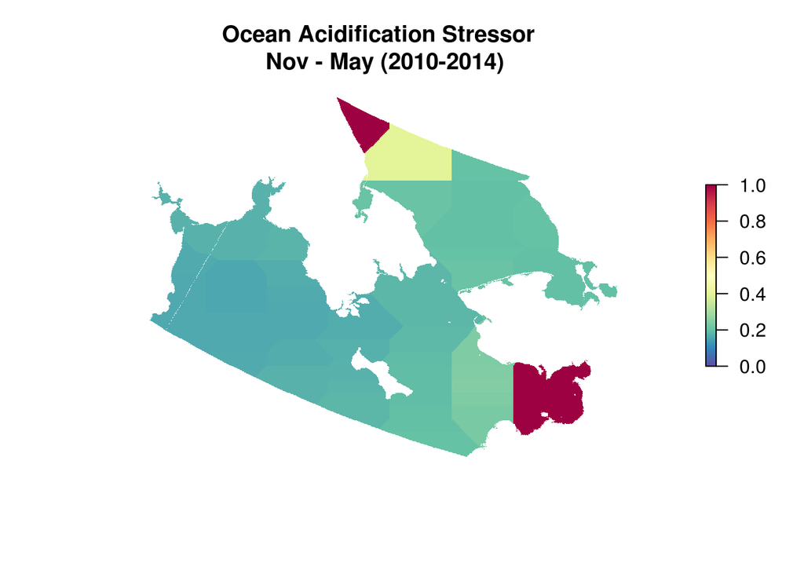

```r
bsr_ice     = list.files('output/bsr/ice_season',full.names=T)
bsr_icefree = list.files('output/bsr/icefree_season',full.names=T)

#get 4 year average for the BSR ice season
    bsr_ice_4yr = stack(bsr_ice[substr(bsr_ice,48,49) %in% c(10,11,12,13)])%>%
                   calc(.,fun=function(x){mean(x,na.rm=T)},progress='text')


    plot(bsr_ice_4yr,zlim=c(0,1),col=cols,box=F,axes=F, main = 'Ocean Acidification Stressor \n Nov - May (2010-2014)')
```

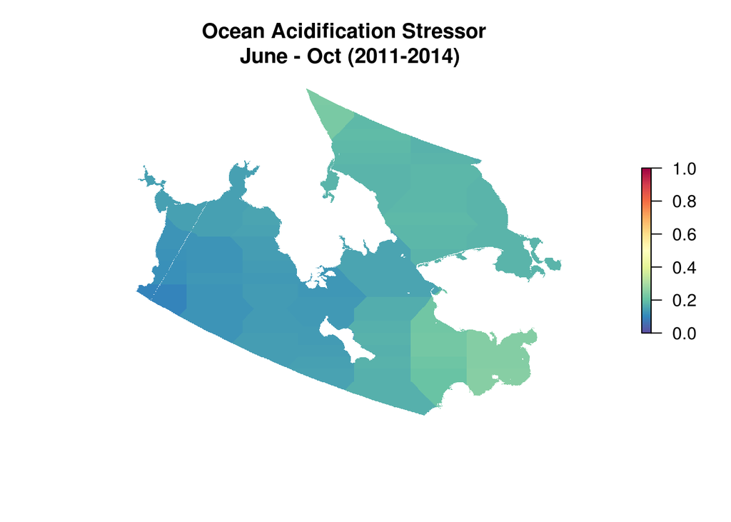

```r
    writeRaster(bsr_ice_4yr,filename='../seasonal_output/oa_avg_iceseason_2010-2014.tif',overwrite=T)

#get 4 year average for the BSR icefree season

bsr_icefree_4yr = stack(bsr_icefree[substr(bsr_icefree,52,55) %in% c(2011:2014)])%>%
                    calc(.,fun=function(x){mean(x,na.rm=T)},progress='text')

    plot(bsr_icefree_4yr,zlim=c(0,1),col=cols,box=F,axes=F, main='Ocean Acidification Stressor \n June - Oct (2011-2014)')
```

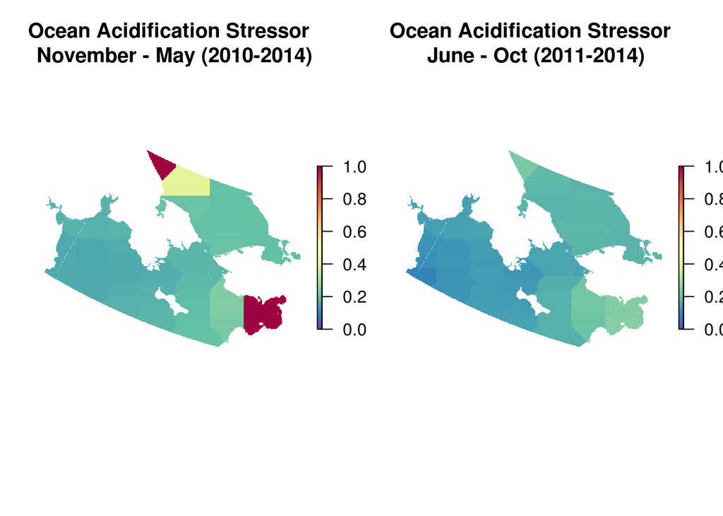

```r
    writeRaster(bsr_ice_4yr,filename='../seasonal_output/oa_avg_icefreeseason_2011-2014.tif',overwrite=T)


par(mfrow=c(1,2))
plot(bsr_ice_4yr,col=cols, box=F,axes=F,main='Ocean Acidification Stressor \n November - May (2010-2014)', zlim=c(0,1))
plot(bsr_icefree_4yr,zlim=c(0,1),col=cols,box=F,axes=F, main='Ocean Acidification Stressor \n June - Oct (2011-2014)')
```

Get 4 year pan-arctic OA layer for ice and ice-free seasons

```
##
  |
  |                                                                 |   0%
```

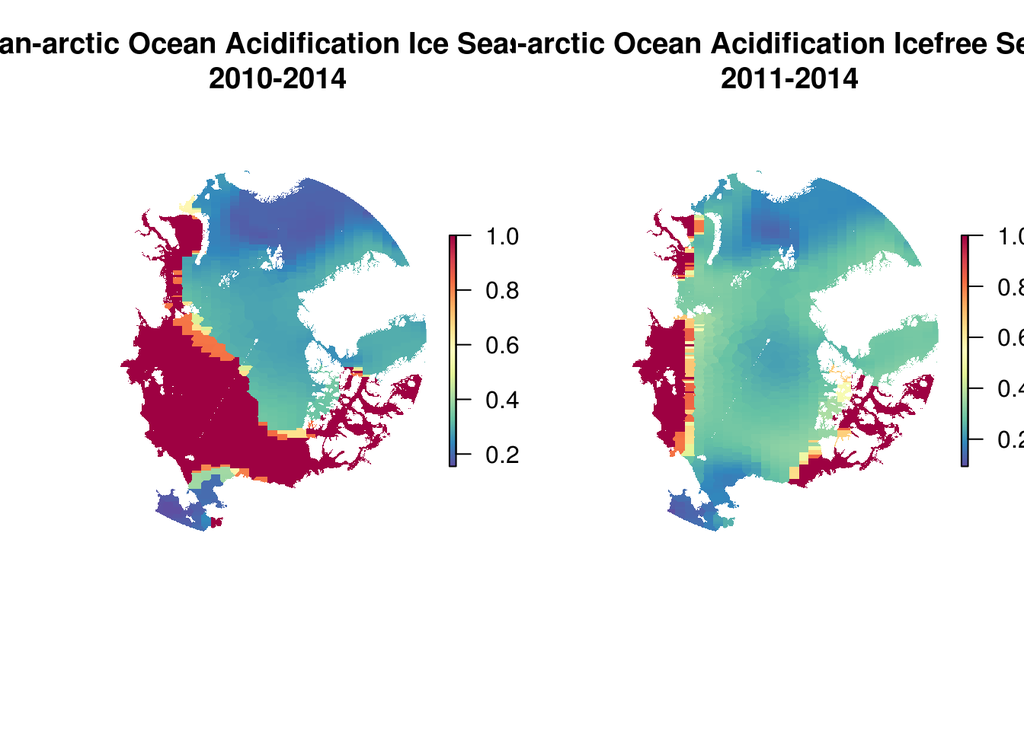

### Step 7: Create a raster showing what cells were interpolated

The original data rescaled and resampled, before interpolation (grab one of the 10 layers for this - doesn’t matter)

```r
#The original data rescaled and resampled, before interpolation (grab one of the 10 layers for this - doesn't matter)

pan_pre = raster('working/pan-arctic/ice_season/rescaled_1km/oa_rescaled_1km_13-14.tif')

#after interpolation, and after land clipped out

pan_post = raster('output/pan-arctic/ice_season/oa_rescaled_1km_int_clip_13-14.tif')


interp_cells = mask(pan_post,pan_pre,progress='text',inverse=TRUE,filename='output/pan-arctic/oa_interpolated_cells.tif',overwrite=T)
bsr_interp = crop(interp_cells,bsr)%>%mask(.,bsr_ocean,filename='output/bsr/oa_interpolated_cells.tif',overwrite=T)
```

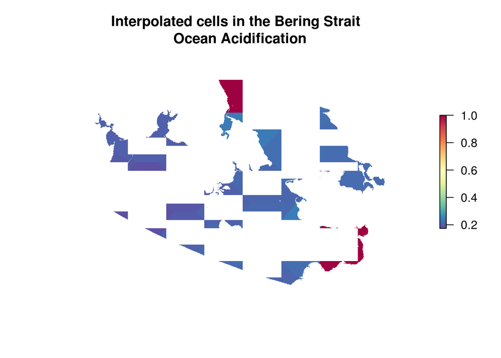

```r
bsr_interp=raster('output/bsr/oa_interpolated_cells.tif')

plot(bsr_interp,col=cols,box=F,axes=F,main='Interpolated cells in the Bering Strait \n Ocean Acidification')
```